# Aside

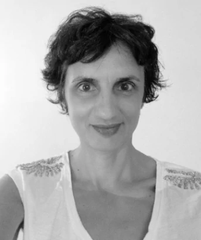

## Profil

- 52 ans, réside à Montferrier-sur-Lez (Hérault)
- 25 ans d’expérience professionnelle
- DESS Economie du développement (Université de Nanterre - Paris X)
- « Visualisation des données avec R-Shiny » « R pour la data science » « Programmation R » (formation continue CEGEFOS)

## Contact

- emmanuelle.sourisseau@d-sidd.com
- [linkedin.com/in/emmanuellesourisseau-datascience](https://www.linkedin.com/in/emmanuellesourisseau-datascience/)
- +33 6 40 64 58 64

## Disclaimer

CV réalisé avec le package R [**pagedown**](https://github.com/rstudio/pagedown).

Dernière mise à jour le 2023-05-22.

# Main

## Emmanuelle Sourisseau

### Statisticienne / Economiste Consultante études et statistiques des territoires

Je propose des outils facilitant la lecture des données, pour développer la connaissance, favoriser la concertation et éclairer la décision. Mon expérience couvre de nombreux domaines d’études : activités, emploi, formation, démographie, infrastructures, mobilités, énergies, logement, permis de construire etc.

## Expérience professionnelle

- Depuis 2022 | Consultante entrepreneuse à T&S et D-SIDD chez CREALEAD
- 2017-2021 | Responsable du site de Montpellier de la CERC Occitanie (observatoire de la filière construction)
- 2011-2017 | Chargée d’études chef de projet CARIF OREF LR/Occitanie (observatoire emploi formation)
- 2010-2011 | Ingénieure en économie au LAMETA (fac.de sciences économiques de Montpellier)
- 2008-2010 | Chargée de mission statistiques à la Province Nord de la Nouvelle-Calédonie
- 2005-2008 | Consultante statisticienne indépendante en Nouvelle-Calédonie
- 2002-2005 | Chef du bureau des statistiques au Vice-Rectorat de Mayotte
- 1996-1998 | Emplois successifs de chargée d’études et de recherche (faculté de sciences économique de Montpellier, IFREMER, CIRAD, SCET)

## Education

Beijing, China

2010

Beijing, China

2014

## Research Experience

Beijing, China

2011 - 2014

- Performed computational biology research towards understanding regulation of alternative splicing in human and mouse transcriptome.
- Found EGFR pathway related mutations, aimed to understand the impacts of cancer mutations on EGFR signaling pathway.

Beijing, China

2015 - 2016

- Investigated how cancer cells spread to other parts of the body at the single cell level.

AL, USA

2016 - 2018

- Investigated the role of mitochondria in development of cancer.
- Investigated the evolution of genome architecture and its role in important evolutionary events.
- Detected thrombotic thrombocytopenic purpura related mutations in mutiple patients’ blood genome.

## Professional Experience

Beijing, China

2014

- Taught R language to beginners.
- Wrote Shiny app demos.
- Converted statistical tutorials from SPSS to R language.

Beijing, China

2015 - 2016

- Analyzed whole-exome sequencing data.
- Wrote analysis pipelines of ChIP-seq, single cell DNA-seq and single cell RNA-seq.
- Studied tumor metastasis and wrote research reports.
- Also did case studies to identify the genetic defect causing rare disease.

## Teaching Experience

Beijing, China

2014

AL, USA

2016 - 2017

## Selected Publications and Posters

Poster for 2013 International Conference of Genomics

Qingdao, China

J Cell Sci. 2016 May 15;129(10):2075-84.

2016